# Soil Moisture Analysis from 2025 Greenhouse Study

Renee Davis

2026-02-03

[GitHub repository](https://github.com/reneeadeledavis/biobead/tree/main/2025greenhouse)

# 1 Methods

## 1.1 Sample Collection

Soil moisture was measured weekly throughout the 8-week wheat growing period. This analysis will focus on weeks 2, 4, 6, 8 in part to evaluate it alongside nutrient leachate data from the same experiment.

## 1.2 Hypotheses and Expectations

1. Hydrogel-containing treatments (T1-T8, T11, T12) will maintain higher soil moisture 24 hours post-watering compared to non-hydrogel treatments (T9, T10, T13, T14) due to water retention properties of the BioBead carrier.
2. Empty bead treatments (T11, T12) will show intermediate moisture retention between BioBead and non-hydrogel treatments, confirming that moisture effects are attributable to the hydrogel carrier rather than microbial activity.
3. Soil moisture differences between hydrogel and non-hydrogel treatments will increase over time as plants grow and water demand increases (time series).

# 2 Results

## 2.1 Week 2 analysis

### 2.1.1 Violin plot

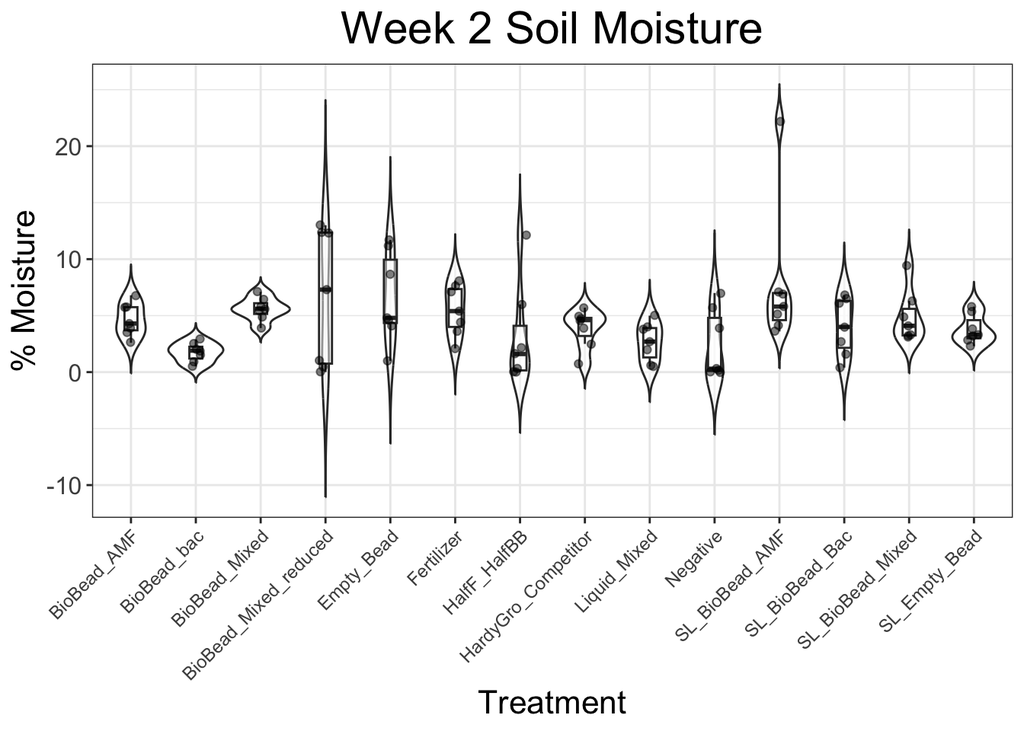

### 2.1.2 One Way ANOVA

```
##                    Df Sum Sq Mean Sq F value Pr(>F)
## Treatment_Category 13  283.2   21.78   2.006 0.0299 *
## Residuals          84  912.3   10.86
## ---
## Signif. codes:  0 '***' 0.001 '**' 0.01 '*' 0.05 '.' 0.1 ' ' 1
```

There were significant differences among treatment groups for soil moisture (F stat (13,84) = 2, p=0.03).

### 2.1.3 Tukey Test

There were significant differences among the following treatment groups for soil moisture: SL_BioBead_AMF and BioBead_bac (p = 0.0499011) with a 6.10% difference in soil moisture. However this a small effect size, and is only borderline significant if we establish an alpha of 0.05.

### 2.1.4 Shapiro Wilk test for normality

```
##
##  Shapiro-Wilk normality test
##
## data:  anova_wk2$residuals
## W = 0.9232, p-value = 2.501e-05
```

### 2.1.5 Residuals distribution

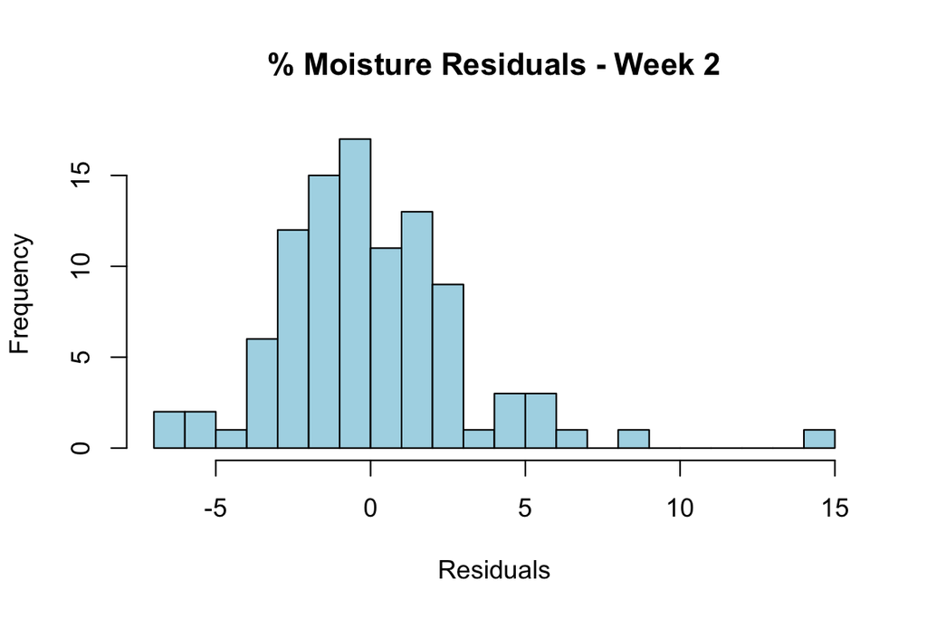

### 2.1.6 Quantile-Quantile plots

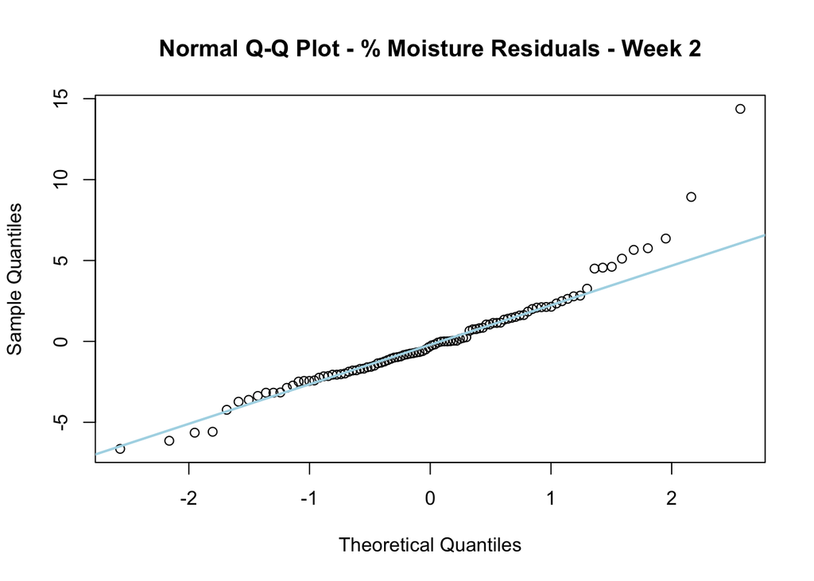

```r
qqnorm(anova_wk2$residuals, main = "Normal Q-Q Plot - % Moisture Residuals - Week 2")
qqline(anova_wk2$residuals, col = "lightblue", lwd = 2)
```

## 2.2 Week 4 analysis

### 2.2.1 Violin plot

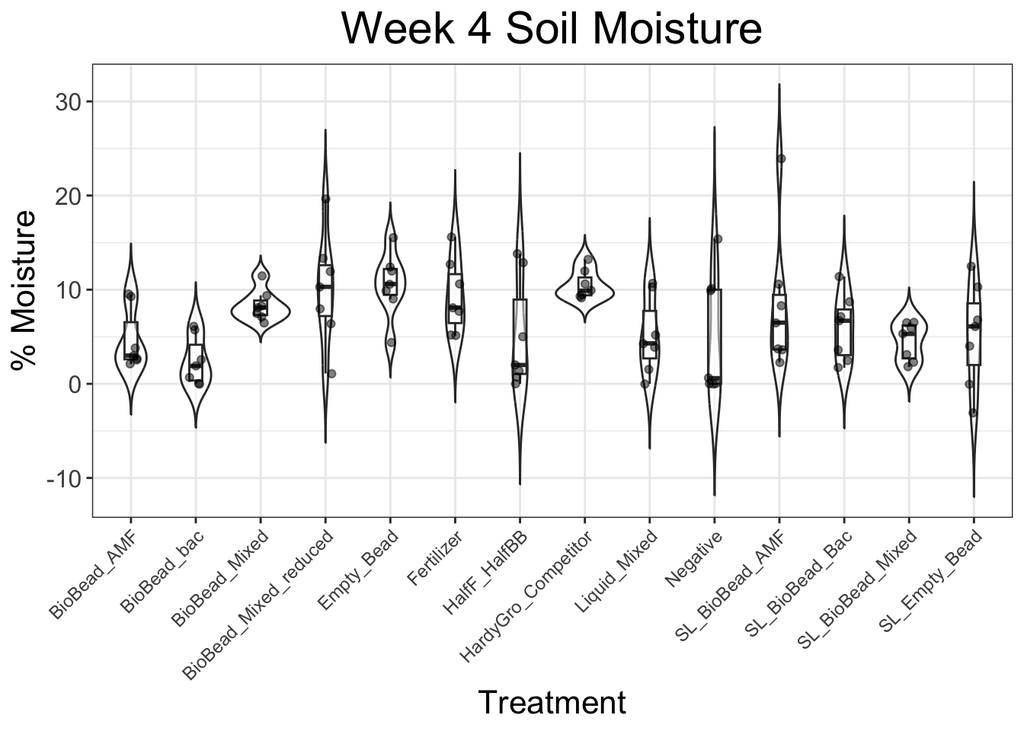

### 2.2.2 One Way ANOVA

```
##                    Df Sum Sq Mean Sq F value  Pr(>F)
## Treatment_Category 13  631.4   48.57   2.448 0.00725 **
## Residuals          84 1666.3   19.84
## ---
## Signif. codes:  0 '***' 0.001 '**' 0.01 '*' 0.05 '.' 0.1 ' ' 1
```

There were significant differences among treatment groups for soil moisture (F stat (13,84) = 2.45, 0.00725).

### 2.2.3 Tukey Test

Post-hoc pairwise comparisons did not reveal significant differences between individual treatment groups after correction for multiple testing. The most promising pairs were HardyGro and BioBead_bac (8.09% moisture, p = 0.0586447) and Empty_Bead and BioBead_bac (8.11% moisture, p = 0.0567438).

### 2.2.4 Shapiro Wilk test for normality

```
##
##  Shapiro-Wilk normality test
##
## data:  anova_wk4$residuals
## W = 0.96539, p-value = 0.01103
```

The W values and low p value (0.97, p = 0.01103) indicate deviation from normality.

### 2.2.5 Residuals distribution

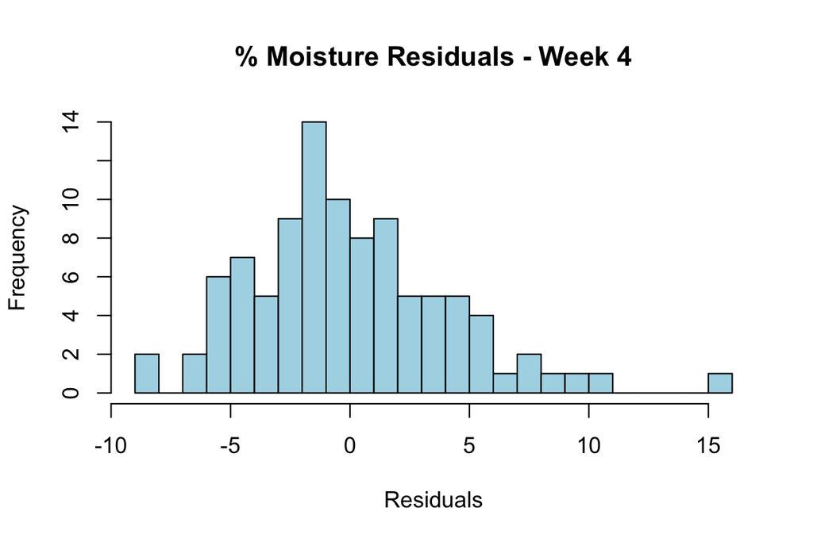

### 2.2.6 Quantile-Quantile plots

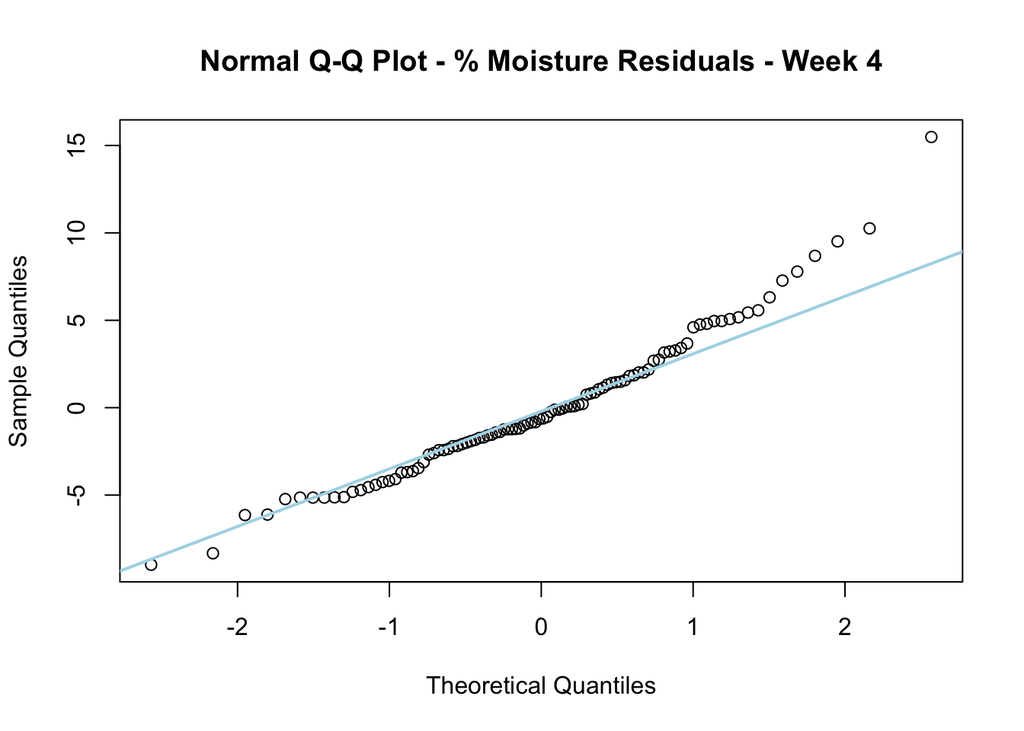

```r
qqnorm(anova_wk4$residuals, main = "Normal Q-Q Plot - % Moisture Residuals - Week 4")
qqline(anova_wk4$residuals, col = "lightblue", lwd = 2)
```

## 2.3 Week 6 analysis

### 2.3.1 Violin plot

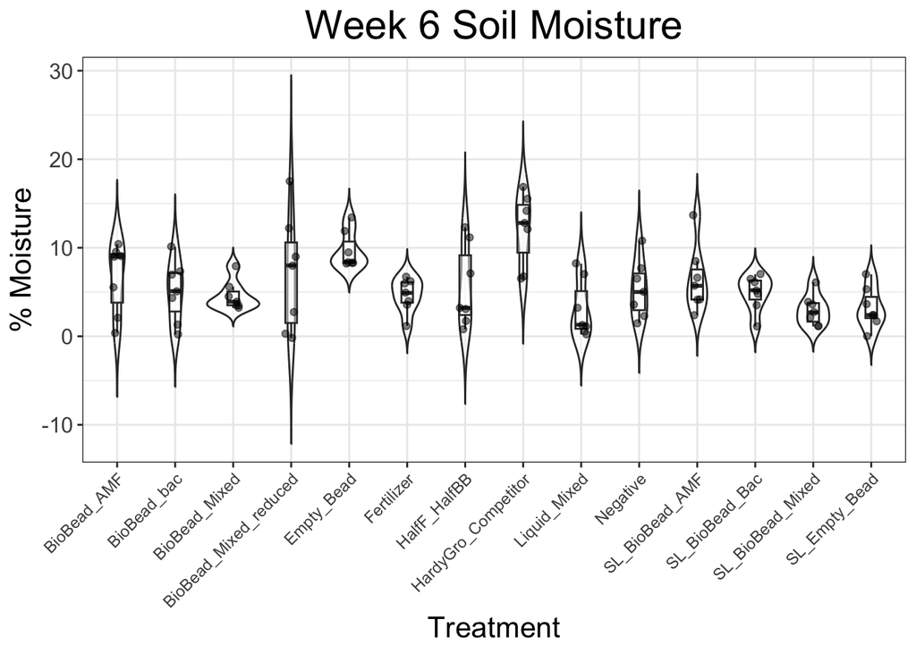

### 2.3.2 One Way ANOVA

```
##                    Df Sum Sq Mean Sq F value  Pr(>F)
## Treatment_Category 13  591.3   45.48   3.801 8.6e-05 ***
## Residuals          84 1005.1   11.97
## ---
## Signif. codes:  0 '***' 0.001 '**' 0.01 '*' 0.05 '.' 0.1 ' ' 1
```

There were significant differences among treatment groups for soil moisture (F stat (13,84) = 3.8, p = 8.6e-05).

### 2.3.3 Tukey Test

Post-hoc pairwise comparisons revealed significant differences between individual the following treatment groups:

- Empty_Bead and SL_BioBead_Mixed (6.75%, p = 0.0279658)
- HardyGro_Competitor and SL_BioBead_Mixed (9.16%, p = 0.0003059)
- HardyGro_Competitor and Liquid_Mixed (9.03%, p = 0.0004000)
- HardyGro_Competitor and SL_Empty_Bead (8.91%, p = 0.0005066)
- HardyGro_Competitor-BioBead_Mixed (7.53%, p = 0.0074483)
- HardyGro_Competitor and Fertilizer (7.46%, p = 0.0084687)
- HardyGro_Competitor and SL_BioBead_Bac (7.23%, p = 0.0126732)
- HardyGro_Competitor and BioBead_bac (7.07%, p = 0.0166016)
- HardyGro_Competitor and Negative (6.77%, p = 0.0273260)
- HardyGro_Competitor and HalfF_HalfBB (6.49%, p = 0.0429524)
- Empty_Bead and Liquid_Mixed (6.63%, p = 0.0343568)

### 2.3.4 Shapiro Wilk test for normality

```
##
##  Shapiro-Wilk normality test
##
## data:  anova_wk6$residuals
## W = 0.99118, p-value = 0.7702
```

The W values and high p value (0.99, p = 0.7702) indicate residual normality.

### 2.3.5 Residuals distribution

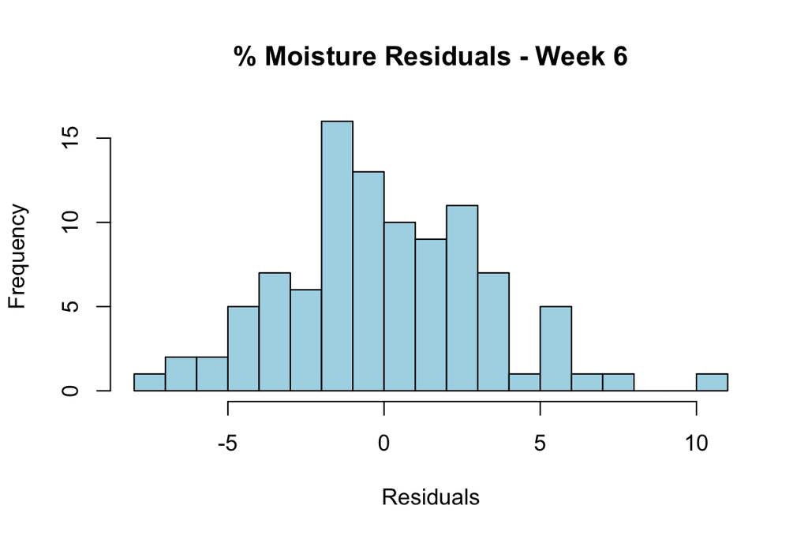

### 2.3.6 Quantile-Quantile plots

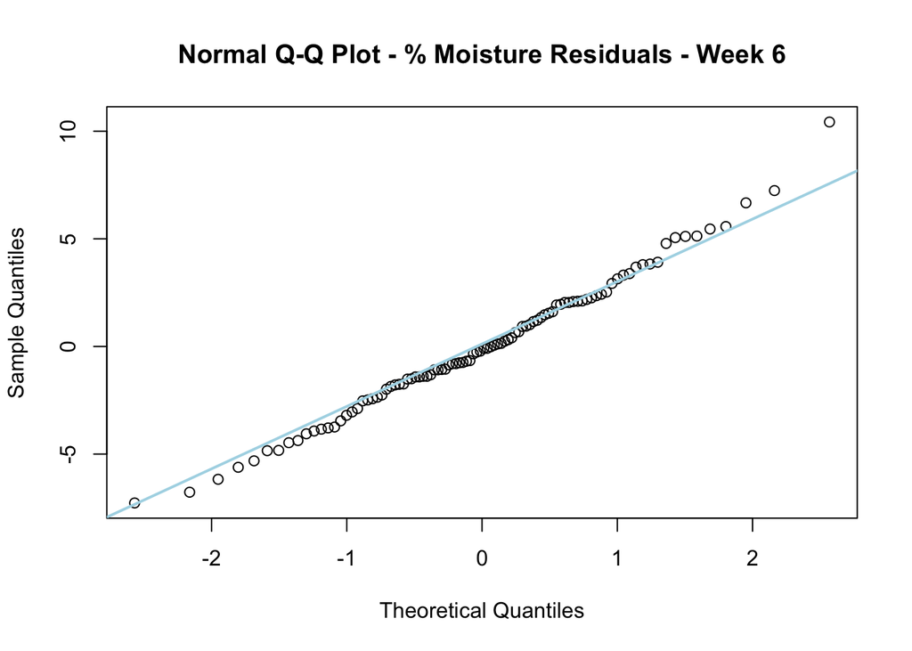

```r
qqnorm(anova_wk6$residuals, main = "Normal Q-Q Plot - % Moisture Residuals - Week 6")
qqline(anova_wk6$residuals, col = "lightblue", lwd = 2)
```

## 2.4 Week 8 analysis

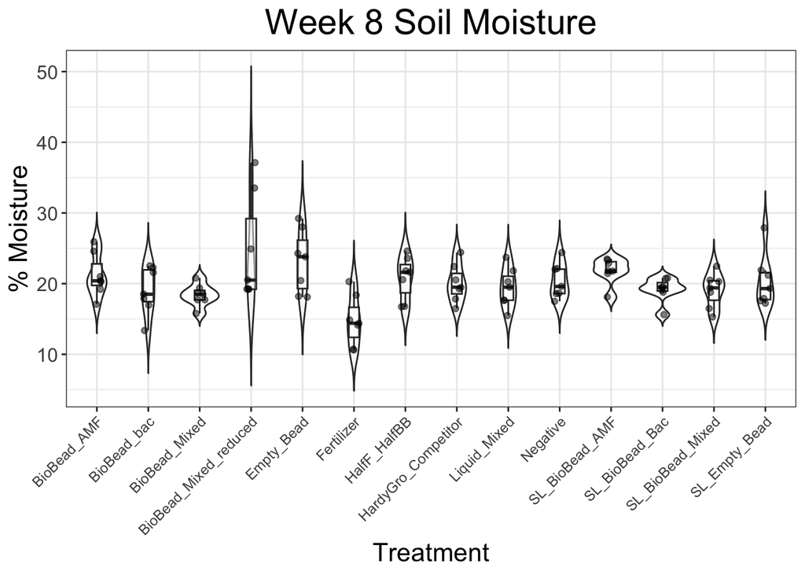

### 2.4.2 One Way ANOVA

```
##                    Df Sum Sq Mean Sq F value   Pr(>F)
## Treatment_Category 13  498.2   38.32   3.164 0.000691 ***
## Residuals          84 1017.3   12.11
## ---
## Signif. codes:  0 '***' 0.001 '**' 0.01 '*' 0.05 '.' 0.1 ' ' 1
```

There were significant differences among treatment groups for soil moisture (F stat (13,84) = 3.164, p = 0.000691).

### 2.4.3 Tukey Test

Post-hoc pairwise comparisons revealed significant differences between individual the following treatment groups:

- BioBead_AMF and Fertilizer (6.44%, p = 0.0486592) - borderline
- SL_BioBead_AMF and Fertilizer (7.06%, p = 0.0182703)
- BioBead_Mixed_reduced and Fertilizer (10.03%, p = 0.0000535)
- BioBead_Mixed_reduced and BioBead_Mixed (6.43%, p = 0.0497186) - borderline

### 2.4.4 Shapiro Wilk test for normality

```
##
##  Shapiro-Wilk normality test
##
## data:  anova_wk8$residuals
## W = 0.96361, p-value = 0.00819
```

The W values and low p value (0.9636, p = 0.00819) indicate deviation from normality.

### 2.4.5 Residuals distribution

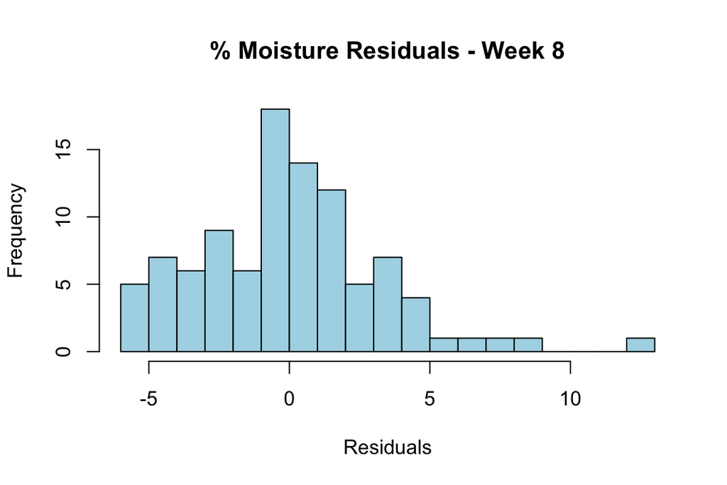

### 2.4.6 Quantile-Quantile plots

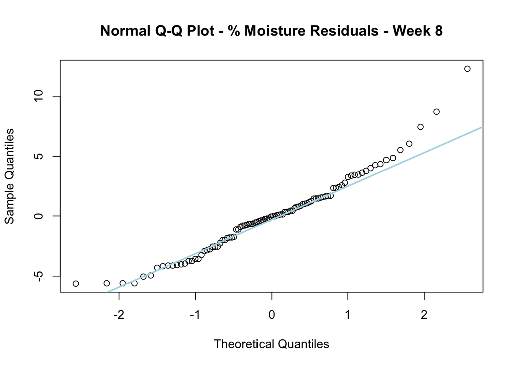

```r
qqnorm(anova_wk8$residuals, main = "Normal Q-Q Plot - % Moisture Residuals - Week 8")
qqline(anova_wk8$residuals, col = "lightblue", lwd = 2)
```

# 3 Discussion

One-way ANOVA revealed differences between treatment groups with respect to soil moisture at different timepoints. There were more signficant effects in the later timepoints.

Post hoc pairwise comparisons revealed standout pairs, but these fluctuated over the different timepoints. Week 2 had a weak signal between SL_BioBead_AMF and BioBead_bac (6.10%, p = 0.0499011). HardyGro and BioBead_bac had signal in week 4. Week 6 saw many pairwise differences with HardyGro and the majority of treatments (9 out of 13). However this did not carry over into the final week, where BioBead_Mixed_reduced, BioBead_AMF, and SL_BioBead_AMF stood out. There is a notable difference from Fertilizer specifically.

This final point bears some emphasis. The BioBead treatments emerging in Week 8 suggests delayed hydrogel effects. Maybe the hydrogels are maintaining moisture better as the system matures and dries out over time.

## 3.1 Next steps

- Try Two-factor ANOVA parsing out hydrogel (T1-7, T11, T12) vs nonhydrogel (T9, T10, T13, T14) treatments.
- Consider non parametric tests like Kruskal-Wallis. ANOVA is reasonably robust to moderate violations in normality, but it’s worth exploring.
- Are these effect sizes (6/10%) meaningful for plant growth?